[figure not shown]

[figure not shown]

[figure not shown]

# Avance del concurso

## Hero

FNDR 8% · Línea 1 · Concurso 2026

Avance de Evaluación

Datos sincronizados · **26-05-2026 · 16:09**

v4 · 2026

## KPIs

Iniciativas

46

Total cargadas

Admisibilidad

100%

46 / 46 evaluadas

Subsanación

0%

0 / 46 resueltas

Eval. Técnica

0%

0 / 46 evaluadas

Priorización

0%

0 / 46 priorizadas

Solicitado GORE

$1.735 MM

Monto total

## Etapas A

Admisibilidad

100% evaluadas

46 iniciativas

Admisibles 7 15% $268 MM Inadmisibles 19 41% $681 MM Observadas 20 43% $786 MM Pendientes 0 0% $0 MM

Subsanación

0% subsanadas

46 aplican

Subsanadas 0 0% $0 MM No subsanadas 0 0% $0 MM Pendientes 1 100% $39 MM No aplica 0 0% $0 MM

## Etapas B

Evaluación técnica

0% evaluadas

46 iniciativas

Aprobadas 0 0% $0 MM Rechazadas 0 0% $0 MM En proceso 0 0% $0 MM Pendientes 46 100% $1.735 MM

Priorización

0% priorizadas

46 iniciativas

Priorizadas 0 0% $0 MM Lista de espera 0 0% $0 MM Pendientes 46 100% $1.735 MM

# Vista territorial

## Filtros

### Filtros activos · aplican al mapa y a la nómina

Provincia

Fondo

Admisibilidad

Subsanación

Eval. Técnica

Priorización

## KPIs Vista

Postulados

46

En admisib.

46

de 46

En eval. téc.

0

de 46

Solicitado GORE

$1.735 MM

Inversión total

$2.399 MM

Beneficiarios

234.121

Comunas

36

9 provincias

## Mapa y fondo

### Mapa de la Región — coloreado por Admisibilidad

[interactive chart not shown]

### Distribución por fondo

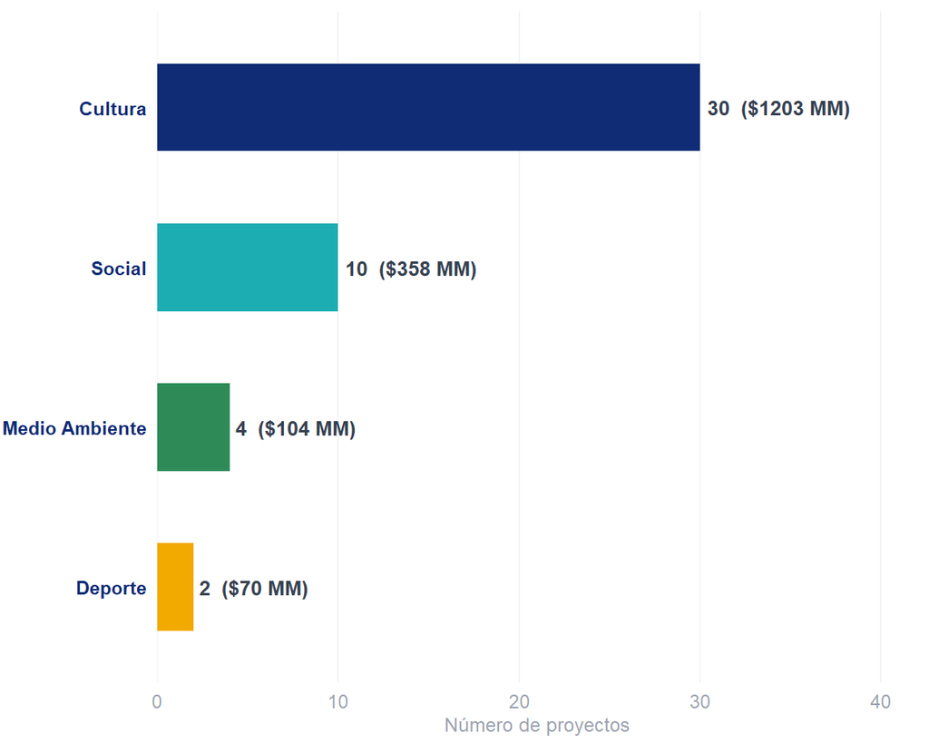

## Provincia y Evaluador

### Proyectos por provincia y fondo

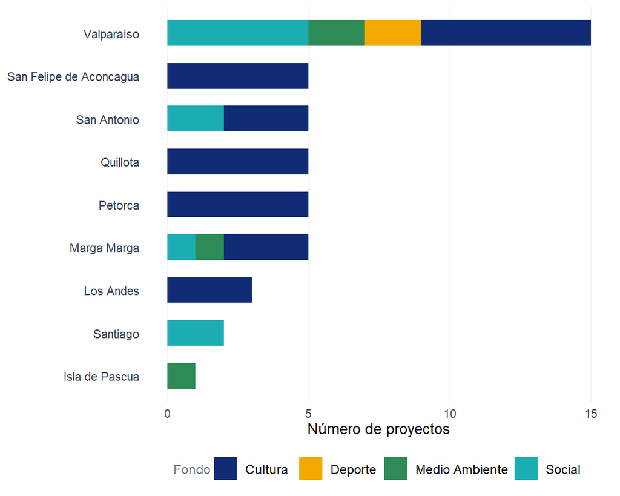

### Carga por evaluador

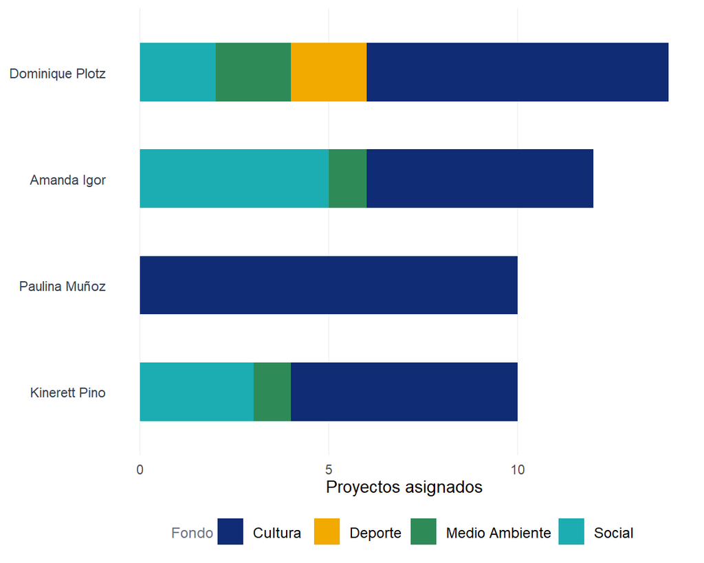

## Nómina

### Nómina filtrable — los filtros de arriba aplican aquí

| N° | Nombre proyecto | Inst. RUT | Inst. Nombre | Inst. Tipo | Inst. Provincia | Inst. Comuna | Aportes propios | Aportes terceros | Territorios | Tipo iniciativa | Masculinos | Femenino | Otres | Admisibilidad | Subsanación | Eval. Técnica | Priorización | Solicitado GORE | Total proyecto | Fondo concurso | Total benef. | Revisión |
| --- | --- | --- | --- | --- | --- | --- | --- | --- | --- | --- | --- | --- | --- | --- | --- | --- | --- | --- | --- | --- | --- | --- |
| 1 | Encuentro Costumbrista El Membrillo 2026 | 69.073.700-0 | Municipalidad de El Tabo | Municipalidad | San Antonio | El Tabo | 80000000 | 0 | Casablanca - La Ligua - San Antonio - El Tabo | Fortalecimiento de las culturas locales y de los pueblos originarios. Actividades como enseñanza de lenguas originarias, difusión de las ceremonias de Pueblos Originarios (we tripantu, inti raymi, Tap… | 4700 | 5600 | 500 | Inadmisible | Inadmisible | No Evaluado | No Priorizado | 39992582 | 119992582 | Cultura | 10800 | Dominique Plotz |
| 2 | V Festival Provincial de la Voz | 69.060.300-4 | I MUNICIPALIDAD DE LA CALERA | Municipalidad | Quillota | Calera | 15000000 | 0 | La Ligua - Quillota - Calera - Hijuelas - La Cruz - Nogales - San Felipe - Llay Llay - Limache | Promoción de las artes y las culturas fomentando iniciativas que contribuyan a la producción, creación y difusión de la música, cine, literatura, poesía, pintura, danza, escultura y oficios, con enfoq… | 2500 | 1500 | 500 | Observado | Admisible | No Evaluado | No Priorizado | 40000000 | 55000000 | Cultura | 4500 | Paulina Muñoz |
| 3 | Festival Violeta al Viento 2027 | 69060400-0 | Ilustre Municipalidad de Llay Llay | Municipalidad | San Felipe de Aconcagua | Llay Llay | 40000000 | 0 | Catemu - Llay Llay | Fortalecimiento de las expresiones de artes musicales en los actores locales, como coros vecinales o comunitarios, bandas de música, entre otros. Incluye actividades como: presentaciones de música, co… | 6500 | 6500 | 2000 | Observado | Admisible | No Evaluado | No Priorizado | 40000000 | 80000000 | Cultura | 15000 | Kinerett Pino |
| 4 | Festival Ranchero Calle Larga 2026 | 69.051.200-9 | Municipalidad de Calle Larga | Municipalidad | Los Andes | Calle Larga | 10000000 | 0 | Los Andes - Calle Larga - San Esteban | Fortalecimiento de las expresiones de artes musicales en los actores locales, como coros vecinales o comunitarios, bandas de música, entre otros. Incluye actividades como: presentaciones de música, co… | 750 | 900 | 50 | Inadmisible | Inadmisible | No Evaluado | No Priorizado | 39286958 | 49286958 | Cultura | 1700 | Dominique Plotz |
| 5 | LIMACHE VIVE CULTURA: Fortaleciendo comunidades por un territorio seguro | 69.061.100-7 | Ilustre Municipalidad de Limache | Municipalidad | Marga Marga | Limache | 10000000 | 0 | Quilpué - Limache - Olmué - Villa Alemana | Implementación de iniciativas de intervención cultural que aporten a la recuperación de espacios públicos a través de actividades creativas, promoviendo capacidades artísticas y culturales en el barri… | 2000 | 3000 | 1000 | Observado | Admisible | No Evaluado | No Priorizado | 40000000 | 50000000 | Cultura | 6000 | Amanda Igor |
| 6 | Feria Costumbrista versión XXI | 69.060.800-6 | Municipalidad de Puchuncaví | Municipalidad | Valparaíso | Puchuncaví | 40000000 | 0 | Concón - Puchuncaví - Quintero - La Ligua - Cabildo - Papudo - Petorca - Zapallar - Limache | Promoción de las artes y las culturas fomentando iniciativas que contribuyan a la producción, creación y difusión de la música, cine, literatura, poesía, pintura, danza, escultura y oficios, con enfoq… | 2400 | 2600 | 0 | Observado | Admisible | No Evaluado | No Priorizado | 40000000 | 80000000 | Cultura | 5000 | Dominique Plotz |
| 7 | FIESTA DE LA PRIMAVERA, COMUNA DE QUINTERO 2026 | 69.060.700-k | I. Municipalidad de Quintero | Municipalidad | Valparaíso | Quintero | 13248000 | 0 | Puchuncaví - Quintero - Petorca - Olmué | Desarrollo cultural de los espacios públicos a través de prácticas artísticas, de mediación cultural y puesta en valor del patrimonio. Actividades tales como: visitas guiadas a espacios históricos - p… | 279 | 311 | 21 | Inadmisible | Inadmisible | No Evaluado | No Priorizado | 40000000 | 53248000 | Cultura | 611 | Paulina Muñoz |
| 8 | Valle Hermoso, Cuna del Tejido: Estrategia intercomunal de fortalecimiento del patrimonio textil mediante formación, implementación de ruta cultural y encuentro de artesanos | 69.050.100-7 | Ilustre Municipalidad de La Ligua | Municipalidad | Petorca | La Ligua | 5000000 | 0 | La Ligua - Cabildo - Papudo - Petorca - Olmué | Desarrollo cultural de los espacios públicos a través de prácticas artísticas, de mediación cultural y puesta en valor del patrimonio. Actividades tales como: visitas guiadas a espacios históricos - p… | 40 | 50 | 0 | Observado | Admisible | No Evaluado | No Priorizado | 39506809 | 44506809 | Cultura | 90 | Paulina Muñoz |
| 9 | Crecer en Movimiento: Oportunidades para la Reinserción Juvenil | 62.000.970-9 | Servicio Nacional de Reinserción Social Juvenil | Entidad Pública | Santiago | Santiago | 0 | 0 | Valparaíso - Casablanca - Concón - Puchuncaví - Quintero - Viña del Mar - Los Andes - Calle Larga - Rinconada - San Esteban - La Ligua - Cabildo - Papudo - Petorca - Zapallar - Quillota - Calera - Hij… | Inclusión social de personas que se encuentran o han estado privadas de libertad, promoviendo su reinserción social, laboral y comunitaria. Incluye acciones como talleres de habilidades socioemocional… | 63 | 2 | 0 | Observado | Admisible | No Evaluado | No Priorizado | 38159533 | 38159533 | Social | 65 | Kinerett Pino |
| 10 | Vive Papudo con Cultura y Tradiciones | 69.050.300-k | Ilustre Municipalidad de Papudo | Municipalidad | Petorca | Papudo | 3000000 | 0 | Puchuncaví - La Ligua - Cabildo - Papudo - Petorca - Zapallar - Olmué | Desarrollo cultural de los espacios públicos a través de prácticas artísticas, de mediación cultural y puesta en valor del patrimonio. Actividades tales como: visitas guiadas a espacios históricos - p… | 4000 | 5000 | 1000 | Inadmisible | Admisible | No Evaluado | No Priorizado | 40000000 | 43000000 | Cultura | 10000 | Kinerett Pino |

[output cut: 36 more lines]

# Panel de control

## Hero panel

FNDR 8% · Línea 1 · Concurso 2026

Panel de control · Resumen ejecutivo

Fondo y provincia computados desde datos en vivo · Motivos desde hoja Panel

v4 · 2026

## Resumen fondo

### Postulados y admisibilidad por fondo

| Fondo | N | Monto | N | Monto | N | Monto | N | Monto |
| --- | --- | --- | --- | --- | --- | --- | --- | --- |
| Cultura | 30 | 1203144698 | 4 | 165839043 | 10 | 397815021 | 16 | 639490634 |
| Social | 10 | 357619229 | 3 | 102339291 | 5 | 187871863 | 2 | 67408075 |
| Medio Ambiente | 4 | 103886394 | 0 | 0 | 3 | 63898584 | 1 | 39987810 |
| Deporte | 2 | 70358206 | 0 | 0 | 1 | 31105078 | 1 | 39253128 |
| TOTAL | 46 | 1735008527 | 7 | 268178334 | 19 | 680690546 | 20 | 786139647 |

## Resumen provincia

### Postulados y admisibilidad por provincia

| Provincia | N | Monto | N | Monto | N | Monto | N | Monto |
| --- | --- | --- | --- | --- | --- | --- | --- | --- |
| Valparaíso | 15 | 526027368 | 4 | 149494244 | 7 | 228031454 | 4 | 148501670 |
| Marga Marga | 5 | 198671900 | 2 | 78684090 | 1 | 40000000 | 2 | 79987810 |
| Petorca | 5 | 198040053 | 0 | 0 | 3 | 118539419 | 2 | 79500634 |
| Quillota | 5 | 199999715 | 0 | 0 | 2 | 79999715 | 3 | 120000000 |
| San Antonio | 5 | 199510084 | 1 | 40000000 | 3 | 119510084 | 1 | 40000000 |
| San Felipe de Aconcagua | 5 | 200000000 | 0 | 0 | 0 | 0 | 5 | 200000000 |
| Los Andes | 3 | 119276958 | 0 | 0 | 1 | 39286958 | 2 | 79990000 |
| Santiago | 2 | 78159533 | 0 | 0 | 1 | 40000000 | 1 | 38159533 |
| Isla de Pascua | 1 | 15322916 | 0 | 0 | 1 | 15322916 | 0 | 0 |
| TOTAL | 46 | 1735008527 | 7 | 268178334 | 19 | 680690546 | 20 | 786139647 |

## Revisoras

### Carga y resultados por revisora

| Revisora | Asignados | Por revisar | Revisados | Admisibles | Inadmisibles | Observados | % adm | % inadm | % obs |
| --- | --- | --- | --- | --- | --- | --- | --- | --- | --- |
| Dominique Plotz | 14 | 0 | 14 | 1 | 8 | 5 | 0.0714285714285714 | 0.571428571428571 | 0.357142857142857 |
| Amanda Igor | 12 | 0 | 12 | 3 | 3 | 6 | 0.25 | 0.25 | 0.5 |
| Kinerett Pino | 10 | 0 | 10 | 2 | 5 | 3 | 0.2 | 0.5 | 0.3 |
| Paulina Muñoz | 10 | 0 | 10 | 1 | 3 | 6 | 0.1 | 0.3 | 0.6 |
| TOTAL | 46 | 0 | 46 | 7 | 19 | 20 | 0.152173913043478 | 0.41304347826087 | 0.434782608695652 |

## Motivos

### Causas de inadmisibilidad

| Causa | Proyectos |
| --- | --- |
| La organización postula a un monto a financiar que se encuentra dentro del máximo planteado en las bases. | 0 |
| La organización se encuentra cumpliendo con lo requerido respecto de las restricciones e inhabilidades (numeral 11). | 0 |
| La organización postulante se deberá encontrar sin rendiciones pendientes con el Gobierno Regional, indicado por la unidad respectiva. | 1 |
| Declaración jurada simple (Anexo N°1) firmada por el Representante Legal o quién tenga las facultades delegadas según corresponda. | 0 |
| Cartas de patrocinio de tres (3) organizaciones de la sociedad civil u organismos del Estado (Anexo Nº 7) para la ejecución de la iniciativa y que sean parte del territorio donde se desarrollará. | 2 |
| “Acreditación de Aportes de Propios" (Anexo Nº4) | 4 |
| “Acreditación de Aportes de Terceros” (Anexos N°5) | 0 |
| Formulario de presupuesto, formato proporcionado por el Gobierno Regional - Excel (Anexo N°2). | 3 |
| Cotizaciones de bienes y servicios. | 19 |
| Tratándose de servicios personales deberá presentar el respectivo currículum, título académico y la cotización de honorarios firmado, formato proporcionado por el Gobierno Regional (Anexo N°6). | 4 |

[output cut: 3 more lines]

### Causas de observación

| Causa | Proyectos |
| --- | --- |
| La organización postula a un monto a financiar que se encuentra dentro del máximo planteado en las bases. | 0 |
| La organización se encuentra cumpliendo con lo requerido respecto de las restricciones e inhabilidades (numeral 11). | 0 |
| La organización postulante se deberá encontrar sin rendiciones pendientes con el Gobierno Regional, indicado por la unidad respectiva. | 0 |
| Declaración jurada simple (Anexo N°1) firmada por el Representante Legal o quién tenga las facultades delegadas según corresponda. | 1 |
| Cartas de patrocinio de tres (3) organizaciones de la sociedad civil u organismos del Estado (Anexo Nº 7) para la ejecución de la iniciativa y que sean parte del territorio donde se desarrollará. | 0 |
| “Acreditación de Aportes de Propios" (Anexo Nº4) | 7 |
| “Acreditación de Aportes de Terceros” (Anexos N°5) | 0 |
| Formulario de presupuesto, formato proporcionado por el Gobierno Regional - Excel (Anexo N°2). | 1 |
| Cotizaciones de bienes y servicios. | 20 |
| Tratándose de servicios personales deberá presentar el respectivo currículum, título académico y la cotización de honorarios firmado, formato proporcionado por el Gobierno Regional (Anexo N°6). | 2 |

[output cut: 3 more lines]

# Acerca

## Info

### Versión 4 — Data-dense moderno · IBM Plex Sans

Versión optimizada para **GitHub Pages** con un look más compacto y editorial. Mantiene la arquitectura estática de `flexdashboard` + `crosstalk`: filtros funcionan en mapa y nómina sin necesidad de servidor.

#### Novedades v4

- **Tipografía IBM Plex Sans** con cifras tabulares (alineación numérica perfecta).
- **Hero propio** arriba con título, última actualización y chip de versión.
- **KPIs compactos** estilo terminal: border-left de color + valor en cifras tabulares.
- **Barras apiladas únicas** por etapa: ves la composición completa de un vistazo, con leyenda inline (% + monto en MM).
- **Mapa CartoDB Voyager** coloreado por admisibilidad — más detalle visual sin saturar.
- **Nómina más densa**, header navy en mayúsculas, chips redondeados.
- **Pestaña Panel de control**: cross-tab por fondo y provincia (computados desde datos en vivo), carga y resultados por revisora, y causas de inadmisibilidad/observación (leídas desde la hoja `Panel`).

#### Qué responde a los filtros

- ✅ Mapa de proyectos
- ✅ Tabla de proyectos

#### Qué NO responde a los filtros

- ❌ KPIs en tarjetas (números fijos)
- ❌ Barras de progreso (página *Avance del concurso*)
- ❌ Gráficos ggplot

Para que **todos** los KPIs y barras se actualicen al filtrar, hay que migrar a Shiny — pero perderías GitHub Pages como hosting.

DIDESOH · Gobierno Regional de Valparaíso

````r
---
title: "Dashboard FNDR 8% Línea 1 — Avance de Evaluación 2026"
author: "DIDESOH · Gobierno Regional de Valparaíso"
date: "Última actualización: `r format(Sys.time(), '%d-%m-%Y · %H:%M')`"
output:
  flexdashboard::flex_dashboard:
    orientation: rows
    vertical_layout: scroll
    social: menu
    source_code: embed
    theme:
      version: 4
      bg: "#FAFAFB"
      fg: "#111827"
      primary: "#0F2C75"
      navbar-bg: "#0F2C75"
      base_font:
        google: IBM Plex Sans
      heading_font:
        google: IBM Plex Sans
      code_font:
        google: IBM Plex Mono
---

```{r setup, include=FALSE}
knitr::opts_chunk$set(echo = FALSE, warning = FALSE, message = FALSE)

library(flexdashboard)
library(dplyr)
library(tidyr)
library(ggplot2)
library(leaflet)
library(sf)
library(chilemapas)
library(reactable)
library(htmltools)
library(crosstalk)

# ============================================================
# 1. CARGA Y NORMALIZACIÓN DE DATOS  (idéntico a v3)
# ============================================================
df <- readRDS("datos_evaluacion.rds")

.norm_colname <- function(s) {
  s <- as.character(s); s <- enc2utf8(s); s <- tolower(trimws(s))
  s <- chartr("áéíóúüñ", "aeiouun", s)
  gsub("[[:space:]_.\u00b7-]+", "", s)
}

rename_if <- function(df, old, new) {
  target <- .norm_colname(old)
  cols_norm <- .norm_colname(names(df))
  hit <- which(cols_norm == target)
  if (length(hit) >= 1) names(df)[hit[1]] <- new
  df
}

df <- df |>
  rename_if("nombre_proyecto",        "Proyecto") |>
  rename_if("fondo",                  "Fondo") |>
  rename_if("provincia",              "Provincia") |>
  rename_if("comuna",                 "Comuna") |>
  rename_if("n_postulacion",          "id") |>
  rename_if("institucion_nombre",    "institucion") |>
  rename_if("monto_solicitado_gore", "monto_gore") |>
  rename_if("monto_aportes_propios", "monto_aportes") |>
  rename_if("beneficiarios_total",   "beneficiarios") |>
  rename_if("Solicitado GORE",      "monto_gore") |>
  rename_if("Aportes propios",      "monto_aportes") |>
  rename_if("Total proyecto",       "monto_total") |>
  rename_if("Beneficiarios",        "beneficiarios") |>
  rename_if("N°",                   "id") |>
  rename_if("Institución",          "institucion") |>
  rename_if("Admisibilidad",        "admisibilidad") |>
  rename_if("Subsanación",          "subsanacion") |>
  rename_if("Evaluación Técnica",   "eval_tecnica") |>
  rename_if("Priorización",         "priorizacion") |>
  rename_if("Comuna",               "Comuna") |>
  rename_if("Provincia",            "Provincia") |>
  rename_if("Fondo",                "Fondo") |>
  rename_if("Proyecto",             "Proyecto")

critical_cols <- c("Comuna", "Provincia", "Fondo", "Proyecto")
missing_cols <- setdiff(critical_cols, names(df))
if (length(missing_cols) > 0) {
  stop("\n❌ Faltan columnas básicas en datos_evaluacion.rds:\n  - ",
       paste(missing_cols, collapse = "\n  - "))
}

etapa_cols <- c("admisibilidad", "subsanacion", "eval_tecnica", "priorizacion")
etapa_missing <- setdiff(etapa_cols, names(df))
if (length(etapa_missing) > 0) {
  message("⚠️ Columnas de etapa ausentes: ", paste(etapa_missing, collapse = ", "))
}

# ============================================================
# 2. CONFIGURACIÓN DE ESTADOS
# ============================================================
config <- list(
  admisibilidad = list(
    label = "Admisibilidad",
    pendiente = "No Evaluado", exitoso = "Admisible",
    rechazado = "Inadmisible", observado = "Observado"
  ),
  subsanacion = list(
    label = "Subsanación",
    pendiente = "Pendiente", exitoso = "Subsanado",
    rechazado = "No Subsanado", no_aplica = "No Aplica"
  ),
  eval_tecnica = list(
    label = "Evaluación Técnica",
    pendiente = "No Evaluado", en_proceso = "En Proceso",
    exitoso = "Aprobado", rechazado = "Rechazado"
  ),
  priorizacion = list(
    label = "Priorización",
    pendiente = "No Priorizado", exitoso = "Priorizado",
    intermedio = "Lista de Espera"
  )
)

ensure_estado <- function(df, col, default) {
  if (!col %in% names(df)) df[[col]] <- default
  v <- as.character(df[[col]]); v <- trimws(v)
  v[is.na(v) | v == ""] <- default
  df[[col]] <- v
  df
}

df <- df |>
  ensure_estado("admisibilidad", config$admisibilidad$pendiente) |>
  ensure_estado("subsanacion",   config$subsanacion$pendiente) |>
  ensure_estado("eval_tecnica",  config$eval_tecnica$pendiente) |>
  ensure_estado("priorizacion",  config$priorizacion$pendiente)

for (cc in c("monto_gore", "monto_aportes", "monto_total", "beneficiarios")) {
  if (cc %in% names(df)) {
    df[[cc]] <- suppressWarnings(as.numeric(df[[cc]]))
    df[[cc]][is.na(df[[cc]])] <- 0
  }
}

# ============================================================
# 3. PALETA + HELPERS
# ============================================================
gore_navy   <- "#0F2C75"
gore_cal    <- "#1CADB2"
gore_oro    <- "#F2A900"
gore_verde  <- "#2E8B57"
gore_rojo   <- "#C0392B"
gore_gris   <- "#9CA3AF"

paleta_fondos <- c(
  "Cultura"             = gore_navy,
  "Social"              = gore_cal,
  "Deporte"             = gore_oro,
  "Medio Ambiente"      = gore_verde,
  "Seguridad Ciudadana" = gore_rojo
)

paleta_admisibilidad <- c(
  "Admisible"   = gore_verde, "Inadmisible" = gore_rojo,
  "Observado"   = gore_oro,   "No Evaluado" = gore_gris
)
paleta_subsanacion <- c(
  "Subsanado"   = gore_verde, "No Subsanado" = gore_rojo,
  "Pendiente"   = gore_oro,   "No Aplica"    = gore_gris
)
paleta_eval_tecnica <- c(
  "Aprobado"    = gore_verde, "Rechazado"    = gore_rojo,
  "En Proceso"  = gore_cal,   "No Evaluado"  = gore_gris
)
paleta_priorizacion <- c(
  "Priorizado"      = gore_verde,
  "Lista de Espera" = gore_cal,
  "No Priorizado"   = gore_gris
)

fmt_clp <- function(x) {
  x <- ifelse(is.na(x) | !is.numeric(x), 0, x)
  paste0("$", formatC(round(x), format = "d", big.mark = ".", decimal.mark = ","))
}
fmt_mm <- function(x) {
  paste0("$", formatC(round(x/1e6), format = "d", big.mark = ".", decimal.mark = ","), " MM")
}
pct <- function(num, den) if (is.na(den) || den == 0) 0 else 100 * num / den
n_val <- function(col, valor) sum(df[[col]] == valor, na.rm = TRUE)
````

```r
# ============================================================
# 4. MÉTRICAS GLOBALES
# ============================================================
n_total      <- nrow(df)
monto_total  <- sum(df$monto_gore, na.rm = TRUE)
n_comunas    <- length(unique(df$Comuna[!is.na(df$Comuna)]))
n_provincias <- length(unique(df$Provincia[!is.na(df$Provincia)]))

n_adm_pendiente <- n_val("admisibilidad", config$admisibilidad$pendiente)
n_adm_admisible <- n_val("admisibilidad", config$admisibilidad$exitoso)
n_adm_inadmis   <- n_val("admisibilidad", config$admisibilidad$rechazado)
n_adm_observ    <- n_val("admisibilidad", config$admisibilidad$observado)
n_adm_evaluadas <- n_total - n_adm_pendiente

n_sub_no_aplica <- n_val("subsanacion", config$subsanacion$no_aplica)
n_sub_pendiente <- n_val("subsanacion", config$subsanacion$pendiente)
n_sub_subsanada <- n_val("subsanacion", config$subsanacion$exitoso)
n_sub_no_subs   <- n_val("subsanacion", config$subsanacion$rechazado)
n_sub_aplica    <- n_total - n_sub_no_aplica

n_tec_pendiente <- n_val("eval_tecnica", config$eval_tecnica$pendiente)
n_tec_proceso   <- n_val("eval_tecnica", config$eval_tecnica$en_proceso)
n_tec_aprobado  <- n_val("eval_tecnica", config$eval_tecnica$exitoso)
n_tec_rechazado <- n_val("eval_tecnica", config$eval_tecnica$rechazado)
n_tec_evaluadas <- n_total - n_tec_pendiente

n_pri_pendiente  <- n_val("priorizacion", config$priorizacion$pendiente)
n_pri_priorizado <- n_val("priorizacion", config$priorizacion$exitoso)
n_pri_lista      <- n_val("priorizacion", config$priorizacion$intermedio)
n_pri_resueltas  <- n_pri_priorizado + n_pri_lista

pct_adm <- pct(n_adm_evaluadas,  n_total)
pct_sub <- pct(n_sub_subsanada,  n_sub_aplica)
pct_tec <- pct(n_tec_evaluadas,  n_total)
pct_pri <- pct(n_pri_priorizado, n_total)

monto_por_estado <- function(col, valor) sum(df$monto_gore[df[[col]] == valor], na.rm = TRUE)

m_adm_admisible <- monto_por_estado("admisibilidad", config$admisibilidad$exitoso)
m_adm_inadmis   <- monto_por_estado("admisibilidad", config$admisibilidad$rechazado)
m_adm_observ    <- monto_por_estado("admisibilidad", config$admisibilidad$observado)
m_adm_pendiente <- monto_por_estado("admisibilidad", config$admisibilidad$pendiente)

m_sub_subsanada <- monto_por_estado("subsanacion", config$subsanacion$exitoso)
m_sub_no_subs   <- monto_por_estado("subsanacion", config$subsanacion$rechazado)
m_sub_pendiente <- monto_por_estado("subsanacion", config$subsanacion$pendiente)
m_sub_no_aplica <- monto_por_estado("subsanacion", config$subsanacion$no_aplica)

m_tec_aprobado  <- monto_por_estado("eval_tecnica", config$eval_tecnica$exitoso)
m_tec_rechazado <- monto_por_estado("eval_tecnica", config$eval_tecnica$rechazado)
m_tec_proceso   <- monto_por_estado("eval_tecnica", config$eval_tecnica$en_proceso)
m_tec_pendiente <- monto_por_estado("eval_tecnica", config$eval_tecnica$pendiente)

m_pri_priorizado <- monto_por_estado("priorizacion", config$priorizacion$exitoso)
m_pri_lista      <- monto_por_estado("priorizacion", config$priorizacion$intermedio)
m_pri_pendiente  <- monto_por_estado("priorizacion", config$priorizacion$pendiente)

# ============================================================
# 5. CENTROIDES POR COMUNA
# ============================================================
norm_str <- function(x) {
  x <- as.character(x); x[is.na(x)] <- ""
  x <- enc2utf8(x); x <- tolower(trimws(x))
  x <- chartr("áéíóúüñ", "aeiouun", x)
  gsub("[^a-z ]", "", x)
}

mapa_v <- chilemapas::mapa_comunas |>
  dplyr::filter(codigo_region == "05") |>
  dplyr::left_join(chilemapas::codigos_territoriales, by = "codigo_comuna") |>
  sf::st_as_sf() |> sf::st_transform(4326)
mapa_v$comuna_norm <- norm_str(mapa_v$nombre_comuna)

suppressWarnings({ centroids_sf <- sf::st_centroid(mapa_v) })
coords <- sf::st_coordinates(centroids_sf)
centroides <- data.frame(
  nombre_comuna = mapa_v$nombre_comuna,
  comuna_norm   = mapa_v$comuna_norm,
  lng = coords[, 1], lat = coords[, 2],
  stringsAsFactors = FALSE
)

df$comuna_norm <- norm_str(df$Comuna)
df <- df |> dplyr::left_join(centroides, by = "comuna_norm")

# ============================================================
# 6. SHAREDDATA · CROSSTALK
# ============================================================
sd <- crosstalk::SharedData$new(df, key = ~Proyecto, group = "linea1")

# ============================================================
# 7. HELPERS HTML — versión Bloomberg/Linear, compacta
# ============================================================
kpi_card <- function(label, value, sub = NULL, color = gore_navy) {
  div(class = "kpi-card", style = paste0("border-left-color:", color, ";"),
      div(class = "kpi-label", label),
      div(class = "kpi-value", style = paste0("color:", color, ";"), value),
      if (!is.null(sub)) div(class = "kpi-sub", sub)
  )
}

# Una sola barra apilada por etapa con leyenda inline arriba.
# segments: list de list(label, n, monto, color)
stacked_progress <- function(title, total_label, total_n, segments,
                             pct_principal = NULL, pct_label = NULL) {
  total <- sum(sapply(segments, function(s) s$n))
  if (total == 0) total <- 1  # evita división por 0

  # Leyenda inline arriba
  legend <- div(class = "stk-legend",
    lapply(segments, function(s) {
      pp <- round(100 * s$n / total)
      tags$span(class = "stk-leg-item",
        tags$span(class = "stk-dot", style = paste0("background:", s$color, ";")),
        tags$span(class = "stk-leg-label", s$label),
        tags$span(class = "stk-leg-num", s$n),
        tags$span(class = "stk-leg-pct", paste0(pp, "%")),
        tags$span(class = "stk-leg-amt", fmt_mm(s$monto))
      )
    })
  )

  # Barra apilada
  bar_segments <- lapply(segments, function(s) {
    pp <- 100 * s$n / total
    tags$div(
      class = "stk-seg",
      style = paste0("flex:", s$n, " 0 0; background:", s$color, ";"),
      title = paste0(s$label, ": ", s$n, " (", round(pp), "%)")
    )
  })

  # Header (título + KPI lateral)
  header <- div(class = "stk-header",
    div(class = "stk-title", title),
    if (!is.null(pct_principal)) {
      div(class = "stk-headline",
        tags$span(class = "stk-headline-num", paste0(round(pct_principal), "%")),
        tags$span(class = "stk-headline-label", pct_label %||% "avance")
      )
    },
    div(class = "stk-total",
      tags$span(class = "stk-total-num", total_n),
      tags$span(class = "stk-total-label", total_label)
    )
  )
```

```r
  div(class = "stk-card",
    header,
    div(class = "stk-bar", bar_segments),
    legend
  )
}

`%||%` <- function(a, b) if (!is.null(a)) a else b

estado_color <- function(estado) {
  e <- tolower(as.character(estado))
  if      (grepl("^admisible$|^aprobado|^subsanado$|^priorizado", e)) gore_verde
  else if (grepl("inadmisible|no subsanado|rechazado",            e)) gore_rojo
  else if (grepl("observado",                                     e)) gore_oro
  else if (grepl("en proceso|lista de espera",                    e)) gore_cal
  else if (grepl("no aplica",                                     e)) gore_gris
  else gore_navy
}

# ============================================================
# 8. PANEL DE CONTROL — bloques 1 y 2 computados, bloque 3 leído
# ============================================================

# ---- Bloques 1 y 2: cross-tab admisibilidad por dimensión ----
resumen_admisibilidad <- function(data, group_var) {
  data |>
    dplyr::group_by({{ group_var }}) |>
    dplyr::summarise(
      n_post = dplyr::n(),
      m_post = sum(monto_gore, na.rm = TRUE),
      n_adm  = sum(admisibilidad == config$admisibilidad$exitoso,    na.rm = TRUE),
      m_adm  = sum(monto_gore[admisibilidad == config$admisibilidad$exitoso],   na.rm = TRUE),
      n_ina  = sum(admisibilidad == config$admisibilidad$rechazado,  na.rm = TRUE),
      m_ina  = sum(monto_gore[admisibilidad == config$admisibilidad$rechazado], na.rm = TRUE),
      n_obs  = sum(admisibilidad == config$admisibilidad$observado,  na.rm = TRUE),
      m_obs  = sum(monto_gore[admisibilidad == config$admisibilidad$observado], na.rm = TRUE),
      .groups = "drop"
    ) |>
    dplyr::arrange(dplyr::desc(n_post))
}

agregar_total <- function(d, label_col) {
  total <- d |>
    dplyr::summarise(
      dplyr::across(dplyr::where(is.numeric), \(x) sum(x, na.rm = TRUE))
    )
  total[[label_col]] <- "TOTAL"
  total <- total[, names(d)]
  dplyr::bind_rows(d, total)
}

resumen_fondo <- df |>
  dplyr::filter(!is.na(Fondo) & Fondo != "") |>
  resumen_admisibilidad(Fondo) |>
  dplyr::rename(Fondo = 1) |>
  agregar_total("Fondo")

resumen_provincia <- df |>
  dplyr::filter(!is.na(Provincia) & Provincia != "") |>
  resumen_admisibilidad(Provincia) |>
  dplyr::rename(Provincia = 1) |>
  agregar_total("Provincia")

# ---- Bloque 3: motivos de inadmisibilidad / observación ----
# Leído desde datos_panel.rds. Robusto: si no existe el archivo o no hay
# headers "Estado" reconocibles, devuelve NULL y la sección muestra un placeholder.
panel_raw <- tryCatch(readRDS("datos_panel.rds"), error = function(e) NULL)

extraer_motivos_panel <- function(panel_raw) {
  if (is.null(panel_raw) || nrow(panel_raw) == 0) return(NULL)

  # Convertir a matriz character preservando estructura
  M <- as.data.frame(panel_raw, stringsAsFactors = FALSE)
  M[] <- lapply(M, function(col) trimws(as.character(col)))
  M <- as.matrix(M)
  M[is.na(M)] <- ""

  # Localizar todas las celdas con header "Estado"
  estado_pos <- which(M == "Estado", arr.ind = TRUE)
  if (nrow(estado_pos) == 0) return(NULL)

  resultado <- list()
  for (k in seq_len(nrow(estado_pos))) {
    r <- estado_pos[k, "row"]
    c <- estado_pos[k, "col"]
    if (c + 1 > ncol(M)) next
    cat_header <- M[r, c + 1]
    if (cat_header == "" || cat_header == "Estado") next

    # Recolectar pares (texto, conteo) hasta una fila vacía o un total
    motivos <- character(0); cantidades <- numeric(0)
    if (r + 1 <= nrow(M)) {
      for (i in (r + 1):nrow(M)) {
        texto  <- M[i, c]
        conteo <- M[i, c + 1]
        if (texto == "" || tolower(texto) %in% c("total", "totales")) break
        valor_n <- suppressWarnings(as.numeric(gsub("[^0-9-]", "", conteo)))
        motivos    <- c(motivos, texto)
        cantidades <- c(cantidades, valor_n)
      }
    }
    if (length(motivos) > 0) {
      resultado[[cat_header]] <- data.frame(
        Estado = motivos, N = cantidades,
        stringsAsFactors = FALSE
      )
    }
  }
  resultado
}

motivos_panel <- extraer_motivos_panel(panel_raw)
motivos_inadm <- motivos_panel[["Inadmisible"]]
motivos_obs   <- motivos_panel[["Observado"]]

# ---- Carga por revisora (hoja Panel de revisoras) ----
revisoras_raw <- tryCatch(readRDS("datos_revisoras.rds"), error = function(e) NULL)

procesar_revisoras <- function(raw) {
  if (is.null(raw) || nrow(raw) == 0) return(NULL)

  d <- raw |>
    janitor::clean_names() |>
    dplyr::filter(
      !is.na(revisoras),
      trimws(as.character(revisoras)) != "",
      tolower(trimws(as.character(revisoras))) != "total"
    )

  # Asegurar columnas numéricas (read_sheet a veces devuelve listas)
  for (col in c("asignados", "por_revisar", "revisados",
                "admisibles", "inadmisibles", "observados")) {
    if (col %in% names(d)) {
      d[[col]] <- suppressWarnings(as.numeric(unlist(d[[col]])))
    }
  }

  # Recomputar porcentajes (más robusto y consistente que parsear el sheet)
  d <- d |>
    dplyr::mutate(
      pct_adm   = ifelse(revisados > 0, admisibles    / revisados, 0),
      pct_inadm = ifelse(revisados > 0, inadmisibles  / revisados, 0),
      pct_obs   = ifelse(revisados > 0, observados    / revisados, 0)
    ) |>
    dplyr::select(revisoras, asignados, por_revisar, revisados,
                  admisibles, inadmisibles, observados,
                  pct_adm, pct_inadm, pct_obs) |>
    dplyr::arrange(dplyr::desc(revisados))

  # Fila TOTAL
  total_row <- d |>
    dplyr::summarise(
      revisoras    = "TOTAL",
      asignados    = sum(asignados, na.rm = TRUE),
      por_revisar  = sum(por_revisar, na.rm = TRUE),
      revisados    = sum(revisados, na.rm = TRUE),
      admisibles   = sum(admisibles, na.rm = TRUE),
      inadmisibles = sum(inadmisibles, na.rm = TRUE),
      observados   = sum(observados, na.rm = TRUE)
    ) |>
    dplyr::mutate(
      pct_adm   = ifelse(revisados > 0, admisibles   / revisados, 0),
      pct_inadm = ifelse(revisados > 0, inadmisibles / revisados, 0),
      pct_obs   = ifelse(revisados > 0, observados   / revisados, 0)
    )
```

````r
  dplyr::bind_rows(d, total_row)
}

resumen_revisoras <- procesar_revisoras(revisoras_raw)
```

```{css}
/* ============================================================
   v4 — Data-dense moderno · IBM Plex Sans · estilo Bloomberg/Linear
   ============================================================ */

body, .navbar {
  font-family: 'IBM Plex Sans', -apple-system, BlinkMacSystemFont, sans-serif;
  font-feature-settings: "tnum" 1, "ss01" 1;
}

body { background: #FAFAFB; color: #111827; }

/* Navbar más delgada y con sombra fina */
.navbar {
  min-height: 44px !important;
  border-bottom: 1px solid rgba(255,255,255,0.08);
  box-shadow: 0 1px 0 rgba(15, 44, 117, 0.04);
}
.navbar-brand {
  font-size: 13px !important;
  letter-spacing: 0.4px;
  font-weight: 600 !important;
  padding: 12px 16px !important;
}
.navbar-nav > li > a {
  font-size: 12px !important;
  letter-spacing: 0.3px;
  text-transform: uppercase;
  font-weight: 500 !important;
  padding: 14px 14px !important;
}

/* Compactar layout general de flexdashboard */
.section.level3 { padding: 6px 10px; }
.section.level2 { padding: 0 4px; }
.chart-wrapper { box-shadow: none !important; border-radius: 4px; }
.chart-wrapper .chart-title {
  font-size: 11px !important;
  letter-spacing: 0.6px;
  text-transform: uppercase;
  font-weight: 600 !important;
  color: #4B5563 !important;
  border-bottom: 1px solid #E5E7EB;
  padding: 8px 12px !important;
}
.chart-stage { padding: 8px 12px !important; }

/* ===========================
   HERO propio
   =========================== */
.hero {
  background: linear-gradient(180deg, #FFFFFF 0%, #F4F6FB 100%);
  border-bottom: 1px solid #E5E7EB;
  padding: 14px 22px 12px 22px;
  margin: 0 0 8px 0;
  display: flex;
  align-items: center;
  justify-content: space-between;
  flex-wrap: wrap;
  gap: 12px;
}
.hero-left { display: flex; flex-direction: column; gap: 2px; }
.hero-eyebrow {
  font-size: 10px;
  letter-spacing: 1.6px;
  text-transform: uppercase;
  color: #1CADB2;
  font-weight: 600;
}
.hero-title {
  font-size: 18px;
  font-weight: 600;
  color: #0F2C75;
  letter-spacing: -0.2px;
  line-height: 1.2;
}
.hero-right { display: flex; align-items: center; gap: 10px; flex-wrap: wrap; }
.hero-meta {
  font-size: 11px;
  color: #6B7280;
  font-variant-numeric: tabular-nums;
}
.hero-meta b { color: #111827; font-weight: 600; }
.hero-chip {
  background: #0F2C75;
  color: white;
  font-size: 10px;
  letter-spacing: 0.8px;
  font-weight: 600;
  text-transform: uppercase;
  padding: 3px 9px;
  border-radius: 3px;
}
.hero-dot {
  width: 6px; height: 6px; border-radius: 50%;
  background: #2E8B57;
  display: inline-block;
  margin-right: 6px;
  box-shadow: 0 0 0 2px rgba(46, 139, 87, 0.18);
}

/* ===========================
   KPI CARDS — compactos
   =========================== */
.kpi-card {
  background: white;
  border: 1px solid #E5E7EB;
  border-left: 3px solid #0F2C75;
  padding: 10px 12px 9px 12px;
  border-radius: 3px;
  height: 100%;
  display: flex;
  flex-direction: column;
  justify-content: center;
  transition: border-color 0.15s ease;
}
.kpi-card:hover { border-color: #0F2C75; }
.kpi-label {
  font-size: 9.5px;
  letter-spacing: 1.4px;
  color: #6B7280;
  text-transform: uppercase;
  font-weight: 600;
  margin-bottom: 2px;
}
.kpi-value {
  font-size: 24px;
  font-weight: 600;
  line-height: 1.05;
  color: #0F2C75;
  font-variant-numeric: tabular-nums;
  letter-spacing: -0.4px;
}
.kpi-sub {
  font-size: 10.5px;
  color: #9CA3AF;
  margin-top: 2px;
  font-variant-numeric: tabular-nums;
}

/* ===========================
   STACKED PROGRESS CARDS
   =========================== */
.stk-card {
  background: white;
  border: 1px solid #E5E7EB;
  border-radius: 4px;
  padding: 12px 14px 11px 14px;
  margin: 0 4px;
}

.stk-header {
  display: flex;
  align-items: baseline;
  gap: 14px;
  margin-bottom: 8px;
  flex-wrap: wrap;
}
.stk-title {
  font-size: 12px;
  letter-spacing: 1.2px;
  text-transform: uppercase;
  font-weight: 600;
  color: #0F2C75;
  flex: 1;
}
.stk-headline {
  display: flex;
  align-items: baseline;
  gap: 5px;
}
.stk-headline-num {
  font-size: 22px;
  font-weight: 600;
  color: #0F2C75;
  font-variant-numeric: tabular-nums;
  letter-spacing: -0.4px;
  line-height: 1;
}
.stk-headline-label {
  font-size: 9.5px;
  letter-spacing: 1.2px;
  text-transform: uppercase;
  color: #9CA3AF;
  font-weight: 600;
}
.stk-total {
  display: flex;
  align-items: baseline;
  gap: 5px;
  padding-left: 14px;
  border-left: 1px solid #E5E7EB;
}
.stk-total-num {
  font-size: 14px;
  font-weight: 600;
  color: #111827;
  font-variant-numeric: tabular-nums;
}
.stk-total-label {
  font-size: 9.5px;
  letter-spacing: 1px;
  text-transform: uppercase;
  color: #9CA3AF;
  font-weight: 600;
}

.stk-bar {
  display: flex;
  width: 100%;
  height: 12px;
  background: #F3F4F6;
  border-radius: 2px;
  overflow: hidden;
  margin-bottom: 8px;
}
.stk-seg {
  height: 100%;
  transition: filter 0.15s ease;
}
.stk-seg:hover { filter: brightness(1.08); }
.stk-seg + .stk-seg { box-shadow: inset 1px 0 0 rgba(255,255,255,0.6); }

.stk-legend {
  display: flex;
  flex-wrap: wrap;
  gap: 4px 16px;
  font-variant-numeric: tabular-nums;
}
.stk-leg-item {
  display: inline-flex;
  align-items: center;
  gap: 6px;
  font-size: 11px;
  color: #4B5563;
  white-space: nowrap;
}
.stk-dot {
  width: 8px;
  height: 8px;
  border-radius: 2px;
  display: inline-block;
}
.stk-leg-label {
  color: #374151;
  font-weight: 500;
}
.stk-leg-num {
  color: #111827;
  font-weight: 600;
  margin-left: 2px;
}
.stk-leg-pct {
  color: #6B7280;
  font-size: 10.5px;
}
.stk-leg-amt {
  color: #9CA3AF;
  font-size: 10.5px;
  padding-left: 6px;
  border-left: 1px solid #E5E7EB;
}

/* ===========================
   FILTROS
   =========================== */
.filter-row .form-group { margin-bottom: 0 !important; }
.filter-row label {
  font-size: 9.5px !important;
  letter-spacing: 1px;
  color: #6B7280 !important;
  font-weight: 600 !important;
  text-transform: uppercase;
  margin-bottom: 3px !important;
}
.filter-row .selectize-input {
  font-size: 11.5px !important;
  padding: 4px 8px !important;
  min-height: 28px !important;
  border-radius: 3px !important;
  border-color: #D1D5DB !important;
  box-shadow: none !important;
}
.filter-row .selectize-input.focus {
  border-color: #0F2C75 !important;
  box-shadow: 0 0 0 2px rgba(15, 44, 117, 0.08) !important;
}
.crosstalk-input { margin-bottom: 4px !important; }
````

````r
/* ===========================
   REACTABLE — más densa
   =========================== */
.rt-table { font-size: 12px; }
.rt-th {
  font-size: 10px !important;
  letter-spacing: 0.8px;
  text-transform: uppercase;
}
.rt-td { padding: 6px 8px !important; }
.rt-search {
  font-size: 12px !important;
  border-radius: 3px !important;
  border: 1px solid #D1D5DB !important;
  padding: 6px 10px !important;
}

/* ===========================
   LEAFLET ajustes
   =========================== */
.leaflet-container {
  font-family: 'IBM Plex Sans', sans-serif !important;
  font-size: 12px !important;
}
.leaflet-control-attribution { font-size: 9px !important; }
.info.legend {
  background: rgba(255,255,255,0.96) !important;
  border: 1px solid #E5E7EB !important;
  border-radius: 3px !important;
  padding: 8px 10px !important;
  font-size: 11px !important;
  box-shadow: 0 2px 6px rgba(0,0,0,0.06) !important;
}

/* About page */
.about-card {
  background: white;
  border: 1px solid #E5E7EB;
  border-radius: 4px;
  padding: 20px 24px;
  max-width: 820px;
  margin: 8px;
}
.about-card h3 { color: #0F2C75; font-size: 16px; font-weight: 600; margin-top: 0; }
.about-card h4 { color: #0F2C75; font-size: 12px; letter-spacing: 0.8px; text-transform: uppercase; margin-top: 18px; margin-bottom: 6px; }
.about-card p, .about-card li { font-size: 13px; line-height: 1.55; color: #374151; }
.about-callout {
  background: #FFF7ED;
  border-left: 3px solid #F2A900;
  padding: 10px 14px;
  font-size: 12.5px;
  margin: 14px 0;
  border-radius: 3px;
  color: #92400E;
}
```

# Avance del concurso {data-icon="fa-tasks"}

## Hero {data-height=64}

### {.no-title .no-padding}

```{r}
div(class = "hero",
  div(class = "hero-left",
    div(class = "hero-eyebrow", "FNDR 8% · Línea 1 · Concurso 2026"),
    div(class = "hero-title", "Avance de Evaluación")
  ),
  div(class = "hero-right",
    div(class = "hero-meta",
      tags$span(class = "hero-dot"),
      "Datos sincronizados · ",
      tags$b(format(Sys.time(), "%d-%m-%Y · %H:%M"))
    ),
    div(class = "hero-chip", "v4 · 2026")
  )
)
```

## KPIs {data-height=82}

### {.no-title .no-padding}
```{r}
kpi_card("Iniciativas", n_total, "Total cargadas", gore_navy)
```

### {.no-title .no-padding}
```{r}
kpi_card("Admisibilidad",
         paste0(round(pct_adm), "%"),
         paste0(n_adm_evaluadas, " / ", n_total, " evaluadas"),
         gore_cal)
```

### {.no-title .no-padding}
```{r}
kpi_card("Subsanación",
         paste0(round(pct_sub), "%"),
         paste0(n_sub_subsanada, " / ", n_sub_aplica, " resueltas"),
         gore_oro)
```

### {.no-title .no-padding}
```{r}
kpi_card("Eval. Técnica",
         paste0(round(pct_tec), "%"),
         paste0(n_tec_evaluadas, " / ", n_total, " evaluadas"),
         gore_verde)
```

### {.no-title .no-padding}
```{r}
kpi_card("Priorización",
         paste0(round(pct_pri), "%"),
         paste0(n_pri_priorizado, " / ", n_total, " priorizadas"),
         gore_navy)
```

### {.no-title .no-padding}
```{r}
kpi_card("Solicitado GORE", fmt_mm(monto_total), "Monto total", gore_oro)
```

## Etapas A {data-height=140}

### {.no-title .no-padding}
```{r}
stacked_progress(
  title = "Admisibilidad",
  total_label = "iniciativas",
  total_n = n_total,
  pct_principal = pct_adm,
  pct_label = "evaluadas",
  segments = list(
    list(label = "Admisibles",   n = n_adm_admisible, monto = m_adm_admisible, color = gore_verde),
    list(label = "Inadmisibles", n = n_adm_inadmis,   monto = m_adm_inadmis,   color = gore_rojo),
    list(label = "Observadas",   n = n_adm_observ,    monto = m_adm_observ,    color = gore_oro),
    list(label = "Pendientes",   n = n_adm_pendiente, monto = m_adm_pendiente, color = gore_gris)
  )
)
```

### {.no-title .no-padding}
```{r}
stacked_progress(
  title = "Subsanación",
  total_label = "aplican",
  total_n = n_sub_aplica,
  pct_principal = pct_sub,
  pct_label = "subsanadas",
  segments = list(
    list(label = "Subsanadas",    n = n_sub_subsanada, monto = m_sub_subsanada, color = gore_verde),
    list(label = "No subsanadas", n = n_sub_no_subs,   monto = m_sub_no_subs,   color = gore_rojo),
    list(label = "Pendientes",    n = n_sub_pendiente, monto = m_sub_pendiente, color = gore_oro),
    list(label = "No aplica",     n = n_sub_no_aplica, monto = m_sub_no_aplica, color = gore_gris)
  )
)
```

## Etapas B {data-height=140}

### {.no-title .no-padding}
```{r}
stacked_progress(
  title = "Evaluación técnica",
  total_label = "iniciativas",
  total_n = n_total,
  pct_principal = pct_tec,
  pct_label = "evaluadas",
  segments = list(
    list(label = "Aprobadas",  n = n_tec_aprobado,  monto = m_tec_aprobado,  color = gore_verde),
    list(label = "Rechazadas", n = n_tec_rechazado, monto = m_tec_rechazado, color = gore_rojo),
    list(label = "En proceso", n = n_tec_proceso,   monto = m_tec_proceso,   color = gore_cal),
    list(label = "Pendientes", n = n_tec_pendiente, monto = m_tec_pendiente, color = gore_gris)
  )
)
```

### {.no-title .no-padding}
```{r}
stacked_progress(
  title = "Priorización",
  total_label = "iniciativas",
  total_n = n_total,
  pct_principal = pct_pri,
  pct_label = "priorizadas",
  segments = list(
    list(label = "Priorizadas",     n = n_pri_priorizado, monto = m_pri_priorizado, color = gore_verde),
    list(label = "Lista de espera", n = n_pri_lista,      monto = m_pri_lista,      color = gore_cal),
    list(label = "Pendientes",      n = n_pri_pendiente,  monto = m_pri_pendiente,  color = gore_gris)
  )
)
```

# Vista territorial {data-icon="fa-map"}

## Filtros {data-height=72}

### Filtros activos · aplican al mapa y a la nómina

```{r filtros-vista}
htmltools::div(
  class = "filter-row",
  crosstalk::bscols(
    widths = c(2, 2, 2, 2, 2, 2),
    crosstalk::filter_select("flt_prov",  "Provincia",      sd, ~Provincia,     multiple = TRUE),
    crosstalk::filter_select("flt_fondo", "Fondo",          sd, ~Fondo,         multiple = TRUE),
    crosstalk::filter_select("flt_adm",   "Admisibilidad",  sd, ~admisibilidad, multiple = TRUE),
    crosstalk::filter_select("flt_sub",   "Subsanación",    sd, ~subsanacion,   multiple = TRUE),
    crosstalk::filter_select("flt_tec",   "Eval. Técnica",  sd, ~eval_tecnica,  multiple = TRUE),
    crosstalk::filter_select("flt_pri",   "Priorización",   sd, ~priorizacion,  multiple = TRUE)
  )
)
```
````

````r
## KPIs Vista {data-height=82}

### {.no-title .no-padding}
```{r}
kpi_card("Postulados", n_total, NULL, gore_navy)
```

### {.no-title .no-padding}
```{r}
kpi_card("En admisib.", n_adm_evaluadas, paste0("de ", n_total), gore_cal)
```

### {.no-title .no-padding}
```{r}
kpi_card("En eval. téc.", n_tec_evaluadas, paste0("de ", n_total), gore_verde)
```

### {.no-title .no-padding}
```{r}
kpi_card("Solicitado GORE", fmt_mm(monto_total), NULL, gore_oro)
```

### {.no-title .no-padding}
```{r}
inversion_total <- sum(df$monto_total, na.rm = TRUE)
if (inversion_total == 0) inversion_total <- monto_total
kpi_card("Inversión total", fmt_mm(inversion_total), NULL, gore_verde)
```

### {.no-title .no-padding}
```{r}
benef_total <- sum(df$beneficiarios, na.rm = TRUE)
kpi_card("Beneficiarios", formatC(benef_total, format = "d", big.mark = "."), NULL, gore_oro)
```

### {.no-title .no-padding}
```{r}
kpi_card("Comunas", n_comunas, paste0(n_provincias, " provincias"), "#5C6772")
```

## Mapa y fondo {data-height=440}

### Mapa de la Región — coloreado por Admisibilidad

```{r}
df_para_mapa <- df |> dplyr::filter(!is.na(lat), !is.na(lng))
sd_mapa <- crosstalk::SharedData$new(df_para_mapa, key = ~Proyecto, group = "linea1")

# CartoDB Voyager — más detalle y color sin saturar
basemap_url <- "https://{s}.basemaps.cartocdn.com/rastertiles/voyager/{z}/{x}/{y}{r}.png"
basemap_attr <- '&copy; <a href="https://www.openstreetmap.org/copyright">OSM</a> &copy; <a href="https://carto.com/attributions">CARTO</a>'

pal_adm <- leaflet::colorFactor(
  palette  = unname(paleta_admisibilidad),
  domain   = names(paleta_admisibilidad),
  na.color = gore_gris
)

leaflet(sd_mapa, options = leafletOptions(zoomControl = TRUE, scrollWheelZoom = FALSE)) |>
  addTiles(urlTemplate = basemap_url, attribution = basemap_attr) |>
  addPolygons(
    data = mapa_v,
    fillColor = "#E5E7EB", weight = 0.6, opacity = 0.6,
    color = "white", fillOpacity = 0.35,
    label = ~nombre_comuna
  ) |>
  addCircleMarkers(
    lng = ~lng, lat = ~lat,
    radius = 7, weight = 1.5,
    color = "#1F2937",
    fillColor = ~pal_adm(admisibilidad),
    fillOpacity = 0.9, opacity = 0.8,
    popup = ~paste0(
      "<strong>", Proyecto, "</strong><br/>",
      "Fondo: ", Fondo, "<br/>",
      "Comuna: ", Comuna, "<br/>",
      "Monto: ", fmt_clp(monto_gore), "<br/>",
      "<hr style='margin:4px 0'>",
      "Adm.: <b>", admisibilidad, "</b><br/>",
      "Subs.: <b>", subsanacion, "</b><br/>",
      "Téc.: <b>", eval_tecnica, "</b><br/>",
      "Prior.: <b>", priorizacion, "</b>"
    )
  ) |>
  addLegend(
    pal = pal_adm,
    values = names(paleta_admisibilidad),
    title = "Admisibilidad",
    position = "bottomright",
    opacity = 0.9
  ) |>
  setView(lng = -71.45, lat = -32.85, zoom = 8)
```

### Distribución por fondo

```{r}
df_fondo_v <- df |>
  count(Fondo, name = "n") |>
  mutate(monto = sapply(Fondo, function(f) sum(df$monto_gore[df$Fondo == f], na.rm = TRUE))) |>
  arrange(desc(n))

ggplot(df_fondo_v, aes(x = reorder(Fondo, n), y = n, fill = Fondo)) +
  geom_col(width = 0.55) +
  geom_text(aes(label = sprintf("%d  ($%.0f MM)", n, monto / 1e6)),
            hjust = -0.05, size = 3.3, color = "#374151", fontface = "bold",
            family = "IBM Plex Sans") +
  scale_fill_manual(values = paleta_fondos) +
  scale_y_continuous(expand = expansion(mult = c(0, 0.4))) +
  coord_flip() +
  labs(x = NULL, y = "Número de proyectos") +
  theme_minimal(base_size = 11, base_family = "IBM Plex Sans") +
  theme(
    legend.position    = "none",
    panel.grid.major.y = element_blank(),
    panel.grid.minor   = element_blank(),
    panel.grid.major.x = element_line(color = "#F3F4F6"),
    axis.text.y        = element_text(color = "#0F2C75", face = "bold"),
    axis.text.x        = element_text(color = "#9CA3AF"),
    axis.title.x       = element_text(color = "#9CA3AF", size = 9)
  )
```

## Provincia y Evaluador {data-height=360}

### Proyectos por provincia y fondo

```{r}
df_prov_fondo <- df |> count(Provincia, Fondo, name = "n")

ggplot(df_prov_fondo, aes(x = reorder(Provincia, n, sum), y = n, fill = Fondo)) +
  geom_col(width = 0.6) +
  scale_fill_manual(values = paleta_fondos, name = "Fondo") +
  coord_flip() +
  labs(x = NULL, y = "Número de proyectos") +
  theme_minimal(base_size = 10.5, base_family = "IBM Plex Sans") +
  theme(
    legend.position    = "bottom",
    legend.title       = element_text(size = 9, color = "#6B7280"),
    legend.text        = element_text(size = 9),
    panel.grid.major.y = element_blank(),
    panel.grid.minor   = element_blank(),
    panel.grid.major.x = element_line(color = "#F3F4F6"),
    axis.text.y        = element_text(color = "#374151")
  )
```

### Carga por evaluador

```{r}
if ("revisor" %in% names(df) && any(!is.na(df$revisor) & df$revisor != "")) {
  df_evaluador <- df |>
    filter(!is.na(revisor) & revisor != "") |>
    count(revisor, Fondo, name = "n")

  ggplot(df_evaluador, aes(x = reorder(revisor, n, sum), y = n, fill = Fondo)) +
    geom_col(width = 0.55) +
    scale_fill_manual(values = paleta_fondos, name = "Fondo") +
    coord_flip() +
    labs(x = NULL, y = "Proyectos asignados") +
    theme_minimal(base_size = 10.5, base_family = "IBM Plex Sans") +
    theme(
      legend.position    = "bottom",
      legend.title       = element_text(size = 9, color = "#6B7280"),
      legend.text        = element_text(size = 9),
      panel.grid.major.y = element_blank(),
      panel.grid.minor   = element_blank(),
      panel.grid.major.x = element_line(color = "#F3F4F6"),
      axis.text.y        = element_text(color = "#374151")
    )
} else {
  HTML('<div style="padding:36px; text-align:center; color:#6B7280; font-size:12px;
        font-family: IBM Plex Sans, sans-serif;">
    No hay información de evaluadores asignados todavía.
  </div>')
}
```

## Nómina {data-height=560}

### Nómina filtrable — los filtros de arriba aplican aquí

```{r}
chip <- function(value) {
  color <- estado_color(value)
  htmltools::tags$span(
    style = sprintf(
      "background:%s18; color:%s; padding:2px 8px; border-radius:9px; font-size:10.5px; font-weight:600; white-space:nowrap; letter-spacing:0.2px;",
      color, color
    ),
    value
  )
}
````

````r
chip_fondo <- function(value) {
  color <- paleta_fondos[[value]]
  if (is.null(color) || is.na(color)) color <- gore_navy
  htmltools::tags$span(
    style = sprintf(
      "background:%s18; color:%s; padding:2px 8px; border-radius:9px; font-size:10.5px; font-weight:600; letter-spacing:0.2px;",
      color, color
    ),
    value
  )
}

cols_visibles <- list(
  id                       = colDef(name = "N°",                width = 56,  align = "center"),
  Proyecto                 = colDef(name = "Nombre proyecto",   minWidth = 240),
  Fondo                    = colDef(name = "Fondo concurso",    width = 130, cell = chip_fondo),
  institucion_rut          = colDef(name = "Inst. RUT",         width = 110),
  institucion              = colDef(name = "Inst. Nombre",      minWidth = 200),
  institucion_tipo         = colDef(name = "Inst. Tipo",        width = 130),
  institucion_provincia    = colDef(name = "Inst. Provincia",   width = 130),
  institucion_comuna       = colDef(name = "Inst. Comuna",      width = 130),
  monto_gore               = colDef(name = "Solicitado GORE",
                                    format = colFormat(prefix = "$", separators = TRUE, digits = 0),
                                    width = 140),
  monto_aportes            = colDef(name = "Aportes propios",
                                    format = colFormat(prefix = "$", separators = TRUE, digits = 0),
                                    width = 130),
  monto_aportes_terceros   = colDef(name = "Aportes terceros",
                                    format = colFormat(prefix = "$", separators = TRUE, digits = 0),
                                    width = 130),
  monto_total              = colDef(name = "Total proyecto",
                                    format = colFormat(prefix = "$", separators = TRUE, digits = 0),
                                    width = 130),
  revisor                  = colDef(name = "Revisión",          width = 140),
  territorios_de_ejecucion = colDef(name = "Territorios",       minWidth = 240),
  tipo_de_iniciativa       = colDef(name = "Tipo iniciativa",   minWidth = 280),
  beneficiarios            = colDef(name = "Total benef.",
                                    format = colFormat(separators = TRUE), width = 100),
  masculinos               = colDef(name = "Masculinos",
                                    format = colFormat(separators = TRUE), width = 100),
  femenino                 = colDef(name = "Femenino",
                                    format = colFormat(separators = TRUE), width = 100),
  otres                    = colDef(name = "Otres",
                                    format = colFormat(separators = TRUE), width = 80),
  admisibilidad            = colDef(name = "Admisibilidad",     width = 130, cell = chip),
  subsanacion              = colDef(name = "Subsanación",       width = 130, cell = chip),
  eval_tecnica             = colDef(name = "Eval. Técnica",     width = 130, cell = chip),
  priorizacion             = colDef(name = "Priorización",      width = 130, cell = chip)
)

cols_a_ocultar <- setdiff(names(df), names(cols_visibles))
cols_def <- cols_visibles
for (cc in cols_a_ocultar) cols_def[[cc]] <- colDef(show = FALSE)

reactable(
  sd,
  defaultPageSize = 14,
  highlight = TRUE,
  striped   = TRUE,
  compact   = TRUE,
  bordered  = FALSE,
  searchable = TRUE,
  theme = reactableTheme(
    borderColor    = "#E5E7EB",
    stripedColor   = "#F9FAFB",
    highlightColor = "#EFF6FA",
    headerStyle    = list(
      backgroundColor = gore_navy, color = "white",
      fontWeight = "600", letterSpacing = "0.6px",
      fontSize = "10.5px", textTransform = "uppercase"
    ),
    style = list(fontFamily = "IBM Plex Sans, sans-serif", fontSize = "12px")
  ),
  columns = cols_def
)
```

# Panel de control {data-icon="fa-table"}

## Hero panel {data-height=64}

### {.no-title .no-padding}

```{r}
div(class = "hero",
  div(class = "hero-left",
    div(class = "hero-eyebrow", "FNDR 8% · Línea 1 · Concurso 2026"),
    div(class = "hero-title", "Panel de control · Resumen ejecutivo")
  ),
  div(class = "hero-right",
    div(class = "hero-meta",
      tags$span(class = "hero-dot"),
      "Fondo y provincia computados desde datos en vivo · Motivos desde hoja Panel"
    ),
    div(class = "hero-chip", "v4 · 2026")
  )
)
```

## Resumen fondo {data-height=300}

### Postulados y admisibilidad por fondo

```{r}
fmt_moneda <- colFormat(prefix = "$", separators = TRUE, digits = 0)
fmt_n      <- colFormat(separators = TRUE)

estilo_total <- function(label_col, df_local) {
  function(index) {
    if (df_local[[label_col]][index] == "TOTAL") {
      list(background = "#F4F6FB", fontWeight = "700", color = gore_navy,
           borderTop = paste0("1px solid ", gore_navy))
    }
  }
}

celda_negrita_total <- function(v) {
  if (!is.na(v) && v == "TOTAL") htmltools::tags$strong(v) else v
}

reactable_resumen <- function(d, label_col) {
  cols_admisibilidad <- list(
    n_post = colDef(name = "N",     format = fmt_n,      width = 70,  align = "right"),
    m_post = colDef(name = "Monto", format = fmt_moneda, minWidth = 130, align = "right"),
    n_adm  = colDef(name = "N",     format = fmt_n,      width = 70,  align = "right"),
    m_adm  = colDef(name = "Monto", format = fmt_moneda, minWidth = 130, align = "right"),
    n_ina  = colDef(name = "N",     format = fmt_n,      width = 70,  align = "right"),
    m_ina  = colDef(name = "Monto", format = fmt_moneda, minWidth = 130, align = "right"),
    n_obs  = colDef(name = "N",     format = fmt_n,      width = 70,  align = "right"),
    m_obs  = colDef(name = "Monto", format = fmt_moneda, minWidth = 130, align = "right")
  )
  cols_admisibilidad[[label_col]] <- colDef(
    name = label_col, minWidth = 160, cell = celda_negrita_total, sticky = "left"
  )
  d <- d[, c(label_col, setdiff(names(d), label_col))]

  reactable(
    d,
    defaultPageSize = nrow(d),
    highlight = TRUE, compact = TRUE, bordered = FALSE, striped = TRUE,
    rowStyle  = estilo_total(label_col, d),
    columnGroups = list(
      colGroup(name = "Postulados",   columns = c("n_post", "m_post"), align = "center"),
      colGroup(name = "Admisibles",   columns = c("n_adm",  "m_adm"),  align = "center"),
      colGroup(name = "Inadmisibles", columns = c("n_ina",  "m_ina"),  align = "center"),
      colGroup(name = "Observados",   columns = c("n_obs",  "m_obs"),  align = "center")
    ),
    columns = cols_admisibilidad,
    theme = reactableTheme(
      borderColor    = "#E5E7EB",
      stripedColor   = "#F9FAFB",
      highlightColor = "#EFF6FA",
      headerStyle = list(
        backgroundColor = gore_navy, color = "white",
        fontWeight = "600", fontSize = "10px",
        letterSpacing = "0.6px", textTransform = "uppercase"
      ),
      groupHeaderStyle = list(
        backgroundColor = "#1A3D8F", color = "white",
        fontWeight = "600", fontSize = "9.5px",
        letterSpacing = "0.8px", textTransform = "uppercase"
      ),
      style = list(fontFamily = "IBM Plex Sans, sans-serif", fontSize = "12px")
    )
  )
}
````

````r
reactable_resumen(resumen_fondo, "Fondo")
```

## Resumen provincia {data-height=380}

### Postulados y admisibilidad por provincia

```{r}
reactable_resumen(resumen_provincia, "Provincia")
```

## Revisoras {data-height=260}

### Carga y resultados por revisora

```{r}
fmt_pct <- colFormat(percent = TRUE, digits = 0)

# Helper: pinta el número en gris si es 0, en color si > 0
chip_pct <- function(color_alto) {
  function(v) {
    if (is.na(v) || v == 0) {
      htmltools::tags$span(style = "color:#9CA3AF;", "0%")
    } else {
      htmltools::tags$span(
        style = sprintf(
          "color:%s; font-weight:600; font-variant-numeric: tabular-nums;",
          color_alto
        ),
        sprintf("%d%%", round(v * 100))
      )
    }
  }
}

if (!is.null(resumen_revisoras) && nrow(resumen_revisoras) > 0) {
  reactable(
    resumen_revisoras,
    defaultPageSize = nrow(resumen_revisoras),
    highlight = TRUE, compact = TRUE, bordered = FALSE, striped = TRUE,
    rowStyle  = estilo_total("revisoras", resumen_revisoras),
    columnGroups = list(
      colGroup(name = "Carga",        columns = c("asignados", "por_revisar", "revisados"),    align = "center"),
      colGroup(name = "Resultados",   columns = c("admisibles", "inadmisibles", "observados"), align = "center"),
      colGroup(name = "Distribución", columns = c("pct_adm", "pct_inadm", "pct_obs"),          align = "center")
    ),
    columns = list(
      revisoras    = colDef(name = "Revisora", minWidth = 160,
                            cell = celda_negrita_total, sticky = "left"),
      asignados    = colDef(name = "Asignados",    format = fmt_n, width = 95,  align = "right"),
      por_revisar  = colDef(name = "Por revisar",  format = fmt_n, width = 100, align = "right"),
      revisados    = colDef(name = "Revisados",    format = fmt_n, width = 95,  align = "right"),
      admisibles   = colDef(name = "Admisibles",   format = fmt_n, width = 100, align = "right"),
      inadmisibles = colDef(name = "Inadmisibles", format = fmt_n, width = 105, align = "right"),
      observados   = colDef(name = "Observados",   format = fmt_n, width = 100, align = "right"),
      pct_adm      = colDef(name = "% adm",   width = 80, align = "right",
                            cell = chip_pct(gore_verde)),
      pct_inadm    = colDef(name = "% inadm", width = 85, align = "right",
                            cell = chip_pct(gore_rojo)),
      pct_obs      = colDef(name = "% obs",   width = 80, align = "right",
                            cell = chip_pct(gore_oro))
    ),
    theme = reactableTheme(
      borderColor    = "#E5E7EB",
      stripedColor   = "#F9FAFB",
      highlightColor = "#EFF6FA",
      headerStyle = list(
        backgroundColor = gore_navy, color = "white",
        fontWeight = "600", fontSize = "10px",
        letterSpacing = "0.6px", textTransform = "uppercase"
      ),
      groupHeaderStyle = list(
        backgroundColor = "#1A3D8F", color = "white",
        fontWeight = "600", fontSize = "9.5px",
        letterSpacing = "0.8px", textTransform = "uppercase"
      ),
      style = list(fontFamily = "IBM Plex Sans, sans-serif", fontSize = "12px")
    )
  )
} else {
  HTML('<div style="padding:36px; text-align:center; color:#6B7280;
        font-size:12px; font-family: IBM Plex Sans, sans-serif;">
        No se encontraron datos en <code>datos_revisoras.rds</code>.<br/>
        Verifica que la hoja <strong>Panel de revisoras</strong> tenga las columnas
        Revisoras, Asignados, Por revisar, Revisados, Admisibles, Inadmisibles, Observados.
        </div>')
}
```

## Motivos {data-height=420}

### Causas de inadmisibilidad

```{r}
chip_n <- function(color_alto) {
  function(v) {
    color <- if (is.na(v) || v == 0) gore_gris else color_alto
    htmltools::tags$span(
      style = sprintf(
        "color:%s; font-weight:600; font-variant-numeric: tabular-nums;",
        color
      ),
      formatC(ifelse(is.na(v), 0, v), format = "d", big.mark = ".")
    )
  }
}

reactable_motivos <- function(d, color_alto) {
  reactable(
    d,
    defaultPageSize = nrow(d),
    highlight = TRUE, compact = TRUE, bordered = FALSE, striped = TRUE,
    columns = list(
      Estado = colDef(name = "Causa", minWidth = 380),
      N      = colDef(name = "Proyectos", width = 110, align = "right",
                      cell = chip_n(color_alto))
    ),
    theme = reactableTheme(
      borderColor    = "#E5E7EB",
      stripedColor   = "#F9FAFB",
      highlightColor = "#EFF6FA",
      headerStyle = list(
        backgroundColor = gore_navy, color = "white",
        fontWeight = "600", fontSize = "10px",
        letterSpacing = "0.6px", textTransform = "uppercase"
      ),
      style = list(fontFamily = "IBM Plex Sans, sans-serif", fontSize = "12px")
    )
  )
}

placeholder_motivos <- function(msg) {
  HTML(sprintf('<div style="padding:36px; text-align:center; color:#6B7280;
        font-size:12px; font-family: IBM Plex Sans, sans-serif;">%s</div>', msg))
}

if (!is.null(motivos_inadm) && nrow(motivos_inadm) > 0) {
  reactable_motivos(motivos_inadm, gore_rojo)
} else {
  placeholder_motivos("No se encontraron motivos de inadmisibilidad en datos_panel.rds.<br/>Verifica que la hoja <strong>Panel</strong> tenga el header <em>Estado / Inadmisible</em>.")
}
```

### Causas de observación

```{r}
if (!is.null(motivos_obs) && nrow(motivos_obs) > 0) {
  reactable_motivos(motivos_obs, gore_oro)
} else {
  placeholder_motivos("No se encontraron motivos de observación en datos_panel.rds.<br/>Verifica que la hoja <strong>Panel</strong> tenga el header <em>Estado / Observado</em>.")
}
```

# Acerca {data-icon="fa-info-circle"}

## Info {data-height=900}

### Acerca de esta versión

```{r}
HTML(paste0('
<div class="about-card">
  <h3>Versión 4 — Data-dense moderno · IBM Plex Sans</h3>

  <p>Versión optimizada para <strong>GitHub Pages</strong> con un look más compacto y editorial. Mantiene la arquitectura estática de <code>flexdashboard</code> + <code>crosstalk</code>: filtros funcionan en mapa y nómina sin necesidad de servidor.</p>
````

````r
  <h4>Novedades v4</h4>
  <ul>
    <li><strong>Tipografía IBM Plex Sans</strong> con cifras tabulares (alineación numérica perfecta).</li>
    <li><strong>Hero propio</strong> arriba con título, última actualización y chip de versión.</li>
    <li><strong>KPIs compactos</strong> estilo terminal: border-left de color + valor en cifras tabulares.</li>
    <li><strong>Barras apiladas únicas</strong> por etapa: ves la composición completa de un vistazo, con leyenda inline (% + monto en MM).</li>
    <li><strong>Mapa CartoDB Voyager</strong> coloreado por admisibilidad — más detalle visual sin saturar.</li>
    <li><strong>Nómina más densa</strong>, header navy en mayúsculas, chips redondeados.</li>
    <li><strong>Pestaña Panel de control</strong>: cross-tab por fondo y provincia (computados desde datos en vivo), carga y resultados por revisora, y causas de inadmisibilidad/observación (leídas desde la hoja <code>Panel</code>).</li>
  </ul>

  <h4>Qué responde a los filtros</h4>
  <ul>
    <li>✅ Mapa de proyectos</li>
    <li>✅ Tabla de proyectos</li>
  </ul>

  <h4>Qué NO responde a los filtros</h4>
  <ul>
    <li>❌ KPIs en tarjetas (números fijos)</li>
    <li>❌ Barras de progreso (página <em>Avance del concurso</em>)</li>
    <li>❌ Gráficos ggplot</li>
  </ul>

  <div class="about-callout">
    Para que <strong>todos</strong> los KPIs y barras se actualicen al filtrar, hay que migrar a Shiny — pero perderías GitHub Pages como hosting.
  </div>

  <p style="color:#9CA3AF; font-size:11px; margin-top:24px; letter-spacing:0.4px;">
    DIDESOH · Gobierno Regional de Valparaíso
  </p>
</div>
'))
```
````